# Chapter 2: Introduction to R

NAMAN SINGHAL

03/16/2024

# ISLR Book

In this notebook, we will be exploring the content of ISLR Lab 2.3, going through each command while examining the associated observations and summarizing understanding. We will later also solve excercise.

## Lab: Introduction to R

# Basic Commands

R is a function based language. `c()` function is used to concat same datatypes to a higher dimentionality. Below we are transforming integers to a single Vector.

```r
x <- c(1,3,2,5)
x
```

```
## [1] 1 3 2 5
```

The `<-` symbol can be interchanged with `=` to assign values to variables. The difference is that `<-` creates a global variable within the user workspace while `=` creates it locally in a function.

```r
x = c(1,6,2)  # vector
x
```

```
## [1] 1 6 2
```

```r
y = c(1,4,3)
```

Using the `?` before any function we can access the help docs for it.

```r
?c
```

`length()` can be used to check dimentions of a variable in R.

```r
length(x)
```

```
## [1] 3
```

```r
length(y)
```

```
## [1] 3
```

We can use `+` to perform vector addition on vectors with same dimension

```r
x+y
```

```
## [1]  2 10  5
```

To check for variables declared so far in user space we can use `ls()`. We’ve declared only `x` and `y`.

```r
ls()
```

```
## [1] "x" "y"
```

To delete a variable we can use `rm()`, similar to `del()` in python

```r
rm(x,y)
ls()
```

```
## character(0)
```

```r
test_var1 <- 4
test_var2 <- c(1,2,3)
ls()
```

```
## [1] "test_var1" "test_var2"
```

We can also delete all objects in one go by passing all `ls()` returned objects to `rm()`

```r
rm(list=ls())
ls()
```

```
## character(0)
```

`matrix()` - like vectors ve can also create matrices in R with this function.The first argument in data should be a vector. As observed below in method 2, each vector is of same datatype in the matrix. `is.matrix()` similarly tests whether the argument passed is a matrix or not

```r
# Method 1
matrix(c(9,92,19,23,4,0.), nrow = 2)
```

```
##      [,1] [,2] [,3]
## [1,]    9   19    4
## [2,]   92   23    0
```

```r
# Method 2
matrix(c(9,2,19,23,4.1,0.), nrow = 3, ncol=2)
```

```
##      [,1] [,2]
## [1,]    9 23.0
## [2,]    2  4.1
## [3,]   19  0.0
```

From above we observe that R fills the matrix by column. We can change this to make it fill by row.

```r
matrix(c(9,2,19,23,4.1,0.), nrow = 3, ncol=2, byrow = TRUE)
```

```
##      [,1] [,2]
## [1,]  9.0    2
## [2,] 19.0   23
## [3,]  4.1    0
```

`sqrt()` gets the square root of each element passed in argument

```r
x = 4
vec_x = c(3,16,100,7)
mat_x = matrix(vec_x, 2)

# Integer
sqrt(x)
```

```
## [1] 2
```

```r
# Vector
sqrt(vec_x)
```

```
## [1]  1.732051  4.000000 10.000000  2.645751
```

```r
# Matrix
sqrt(mat_x)
```

```
##          [,1]      [,2]
## [1,] 1.732051 10.000000
## [2,] 4.000000  2.645751
```

`^` operator can be used to raise a variable to power

```r
vec_x^3
```

```
## [1]      27    4096 1000000     343
```

We can generate random vectors from a normal distribution with `rnorm()`.

```r
rand_x1 = rnorm(6)
rand_x1
```

```
## [1] -0.3935261 -2.2910863 -0.3631907 -1.0104044  0.6160733 -0.4857878
```

`cor()` is used to check correlation between two variables

```r
rand_y1 = rand_x1 + rnorm(6, mean=20)
rand_y1
```

```
## [1] 19.27031 15.52630 20.05049 17.86510 20.11376 19.07719
```

```r
cor(rand_x1, rand_y1)
```

```
## [1] 0.948736
```

We can set seed to get the same output from a random data gen function

```r
set.seed(3)
```

Following are some useful functions

```r
mean(vec_x)
```

```
## [1] 31.5
```

```r
var(vec_x)
```

```
## [1] 2115
```

```r
sd(vec_x)
```

```
## [1] 45.98913
```

# Graphics

`plot()` can be used to make plots in R. Default plot is scatter.

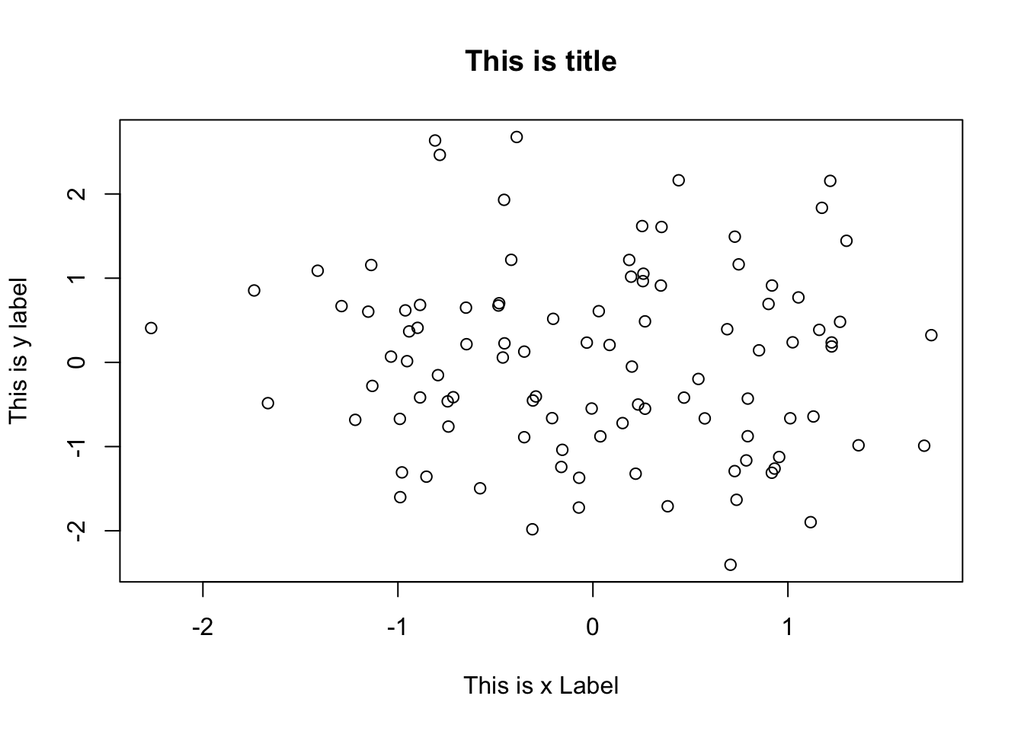

```r
x = rnorm(100)
y=rnorm(100)
plot(x,y, xlab = "This is x Label", ylab = "This is y label",
     main = "This is title")
```

`jpeg()` and `pdf()` can be used to export plots

```r
jpeg("Figuree.png")
plot(x,y,col = "green")
dev.off() # indicates end of plot creation
```

`seq()` can be used to create a vector. Similar to `range()` from python

```r
seq(1,10)
```

```
##  [1]  1  2  3  4  5  6  7  8  9 10
```

```r
seq(-1,1,length=10)
```

```
##  [1] -1.0000000 -0.7777778 -0.5555556 -0.3333333 -0.1111111  0.1111111
##  [7]  0.3333333  0.5555556  0.7777778  1.0000000
```

`pi` represents the math pi in R. `outer()` is a function to get outer product of X and Y arrays. `function()` is a keyword we use to create functions in R. We can create both multiline functions or single line once like `lambda()` in python We will use `contour()` to create a contour plot now. We need the x, y and the z values to make this plot

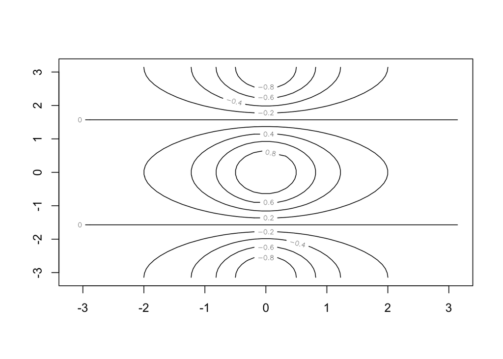

```r
x = y = seq(-pi, pi, length=50)
f = outer(x,y, function(x,y) cos(y)/(1+x^2))
contour(x,y,f)
```

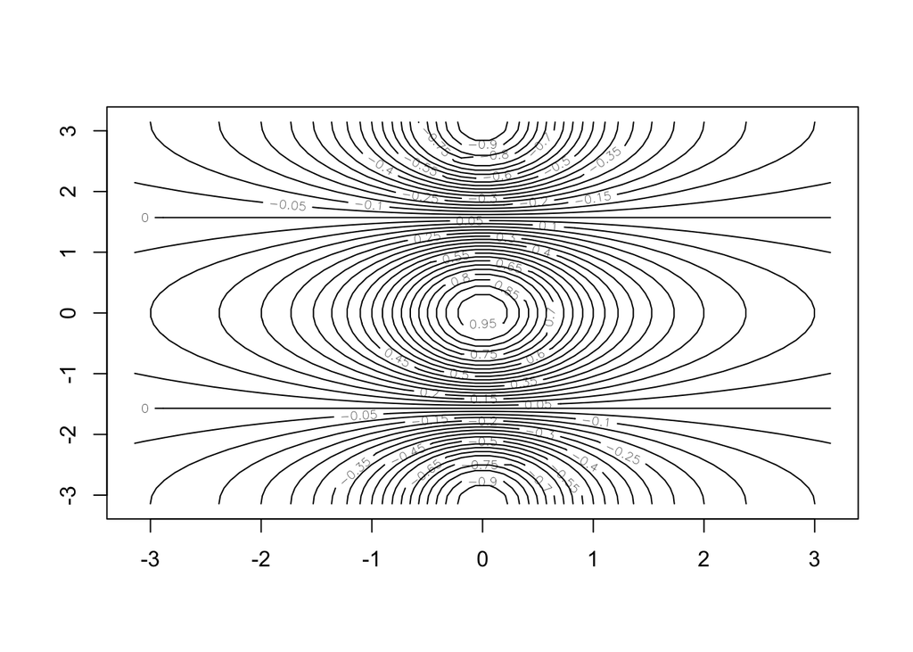

```r
contour(x,y,f, nlevels = 30) # nlevels controls number of lines
```

`image()` gives color to contour maps and produce heatmap. Alternatively, `persp()` creates a 3D plot. `theta` horizontaly rotates the plot and `phi` does it vertically

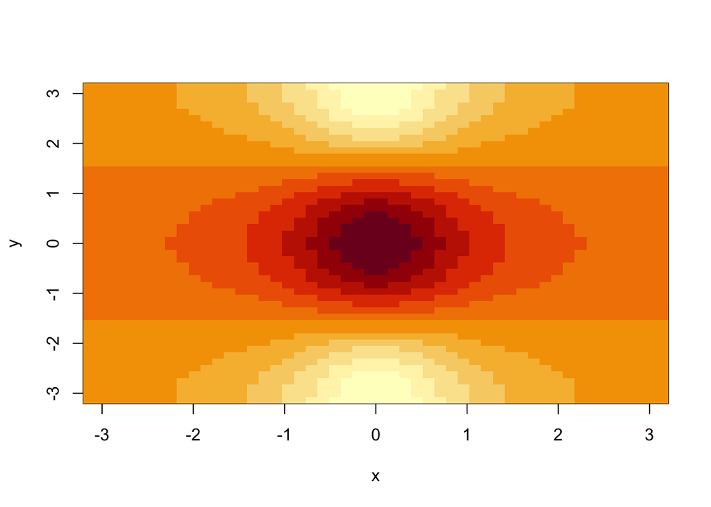

```r
image(x,y,f)
```

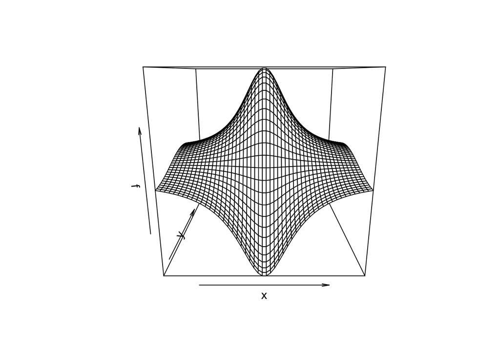

```r
persp(x,y,f)
```

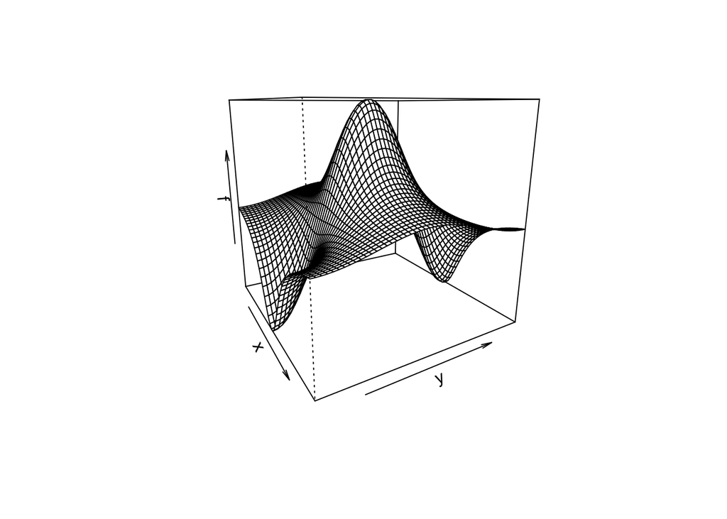

```r
persp(x,y,f, theta = 60)
```

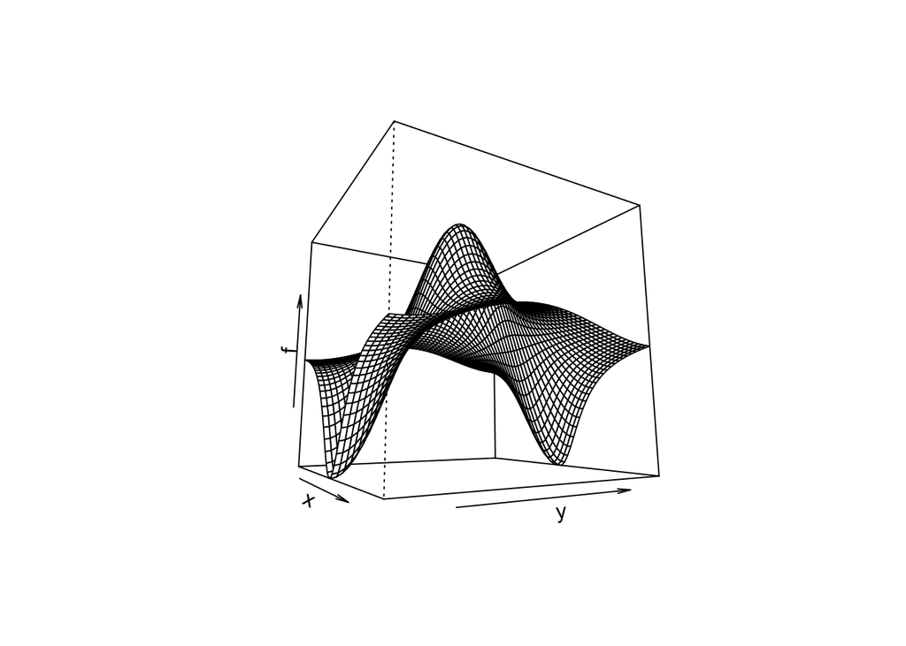

```r
persp(x,y,f, theta = 60, phi=-10)
```

# Indexing Data

1:16 generates numbers 1 to 16. We can then index matrix in following way

```r
A=matrix(1:16, 4,4)
A
```

```
##      [,1] [,2] [,3] [,4]
## [1,]    1    5    9   13
## [2,]    2    6   10   14
## [3,]    3    7   11   15
## [4,]    4    8   12   16
```

```r
A[1,2]
```

```
## [1] 5
```

We can also select a range of rows and columns in matrix.

```r
A[c(1,3), c(2,4)] # Rows 1 and 3, Columns 2 and 4
```

```
##      [,1] [,2]
## [1,]    5   13
## [2,]    7   15
```

```r
A[2:4,1:2]
```

```
##      [,1] [,2]
## [1,]    2    6
## [2,]    3    7
## [3,]    4    8
```

```r
A[, 3:ncol(A)]
```

```
##      [,1] [,2]
## [1,]    9   13
## [2,]   10   14
## [3,]   11   15
## [4,]   12   16
```

```r
A[2,]
```

```
## [1]  2  6 10 14
```

Negative values indicate keep all rows/col except the one specified

```r
A[-c(2, 3),]
```

```
##      [,1] [,2] [,3] [,4]
## [1,]    1    5    9   13
## [2,]    4    8   12   16
```

Checking shape

```r
dim(A)
```

```
## [1] 4 4
```

# Loading Data

`read.table()` and `write.table()` are often used to read write data in R

```r
auto = read.table('Auto.data')
head(auto, 5)
```

```
##     V1        V2           V3         V4     V5           V6   V7     V8
## 1  mpg cylinders displacement horsepower weight acceleration year origin
## 2 18.0         8        307.0      130.0  3504.         12.0   70      1
## 3 15.0         8        350.0      165.0  3693.         11.5   70      1
## 4 18.0         8        318.0      150.0  3436.         11.0   70      1
## 5 16.0         8        304.0      150.0  3433.         12.0   70      1
##                          V9
## 1                      name
## 2 chevrolet chevelle malibu
## 3         buick skylark 320
## 4        plymouth satellite
## 5             amc rebel sst
```

We need to load data properly, we will use the following command parameters

```r
auto = read.table('Auto.data', header=T, na.strings = "?")
dim(auto)
```

```
## [1] 397   9
```

```r
head(auto, 5)
```

```
##   mpg cylinders displacement horsepower weight acceleration year origin
## 1  18         8          307        130   3504         12.0   70      1
## 2  15         8          350        165   3693         11.5   70      1
## 3  18         8          318        150   3436         11.0   70      1
## 4  16         8          304        150   3433         12.0   70      1
## 5  17         8          302        140   3449         10.5   70      1
##                        name
## 1 chevrolet chevelle malibu
## 2         buick skylark 320
## 3        plymouth satellite
## 4             amc rebel sst
## 5               ford torino
```

`na.omit()` removes rows with Nulls

```r
dim(na.omit(auto))
```

```
## [1] 392   9
```

We can get the column names with `names()`

```r
names(auto)
```

```
## [1] "mpg"          "cylinders"    "displacement" "horsepower"   "weight"
## [6] "acceleration" "year"         "origin"       "name"
```

# Additional Graphical and Numerical Summaries

`<table>$<column>` is the syntax we use to fetch certain column `<column>` from table `<table>`

```r
head(auto$cylinders, 20) # Top 20 values from Cylinder column
```

```
##  [1] 8 8 8 8 8 8 8 8 8 8 8 8 8 8 4 6 6 6 4 4
```

`attach()` We can also use this function on a dataframe or table to make R aware of all the column names. Then we wont have to use the above notation.

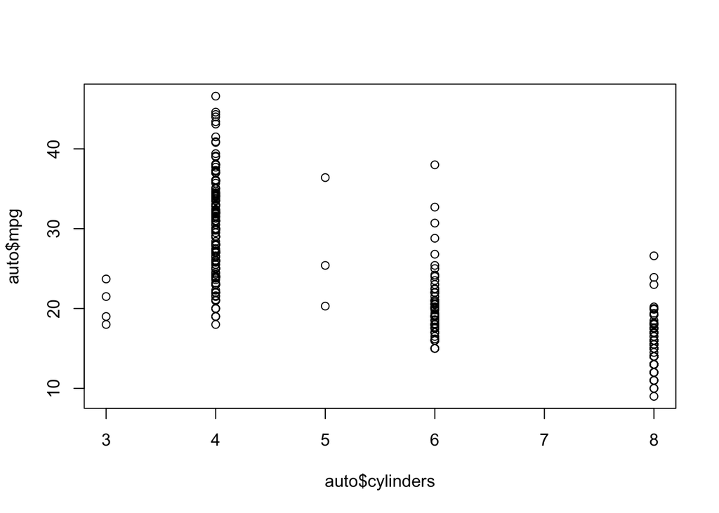

```r
plot(auto$cylinders, auto$mpg)
```

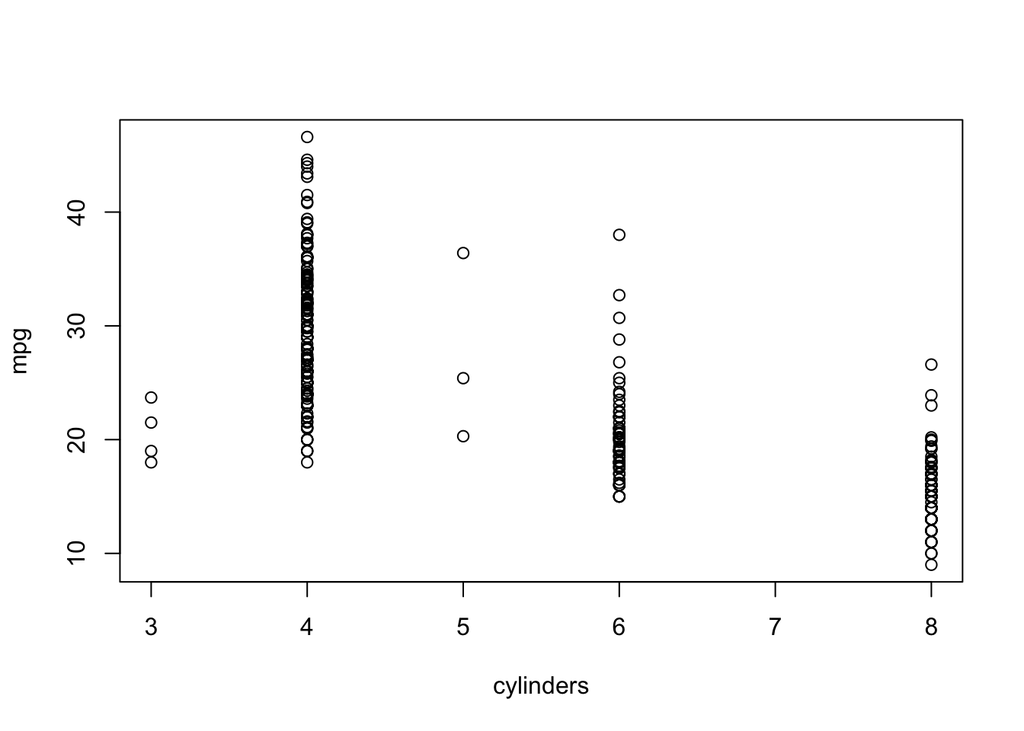

```r
attach(auto)
plot(cylinders, mpg)
```

Because cylinders has numbers R treats it like a Numerical/Quantitative variable. We can convert it to categorical/qualitative variable with `as.factor()`. Doing so will create box plot.

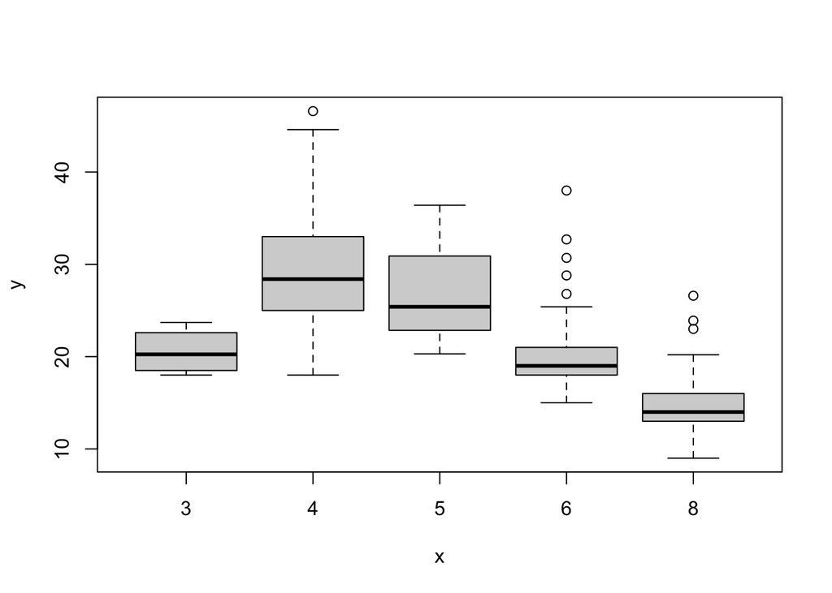

```r
cylinders = as.factor(cylinders)
plot(cylinders, mpg)
```

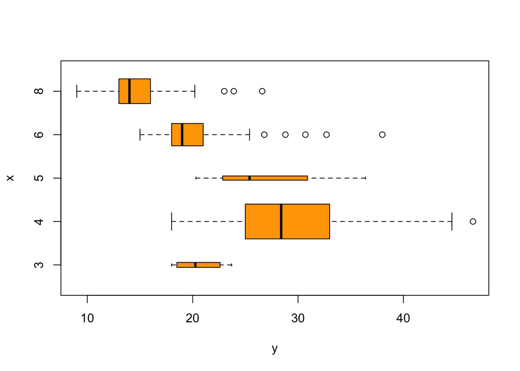

```r
plot(cylinders, mpg, col="orange", varwidth=T, horizontal=T)
```

```r
# varwidth gives thickness to X according to counts
# horizontal makes plot horizontally
```

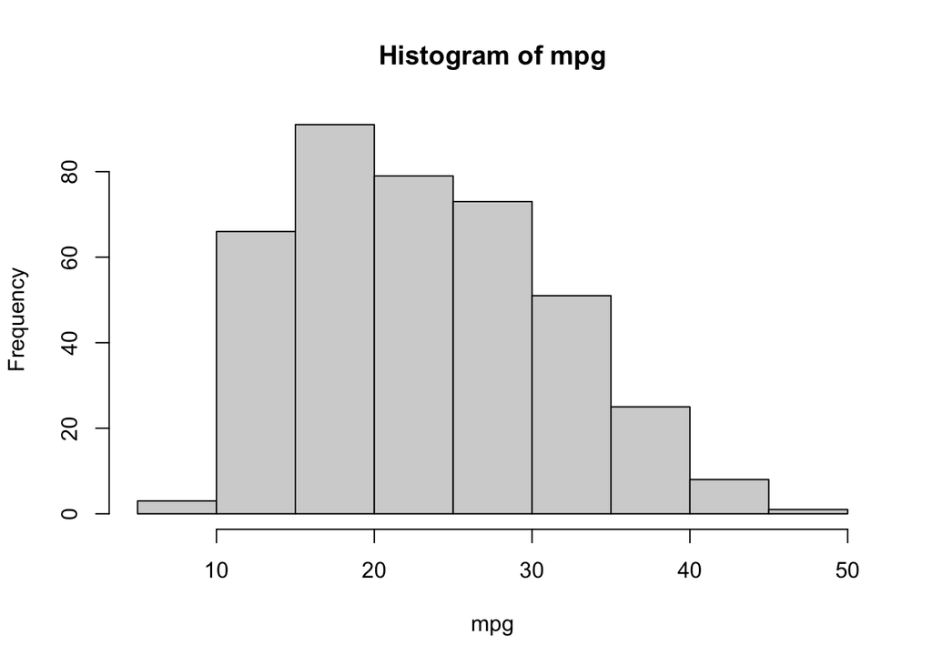

```r
hist(mpg)
```

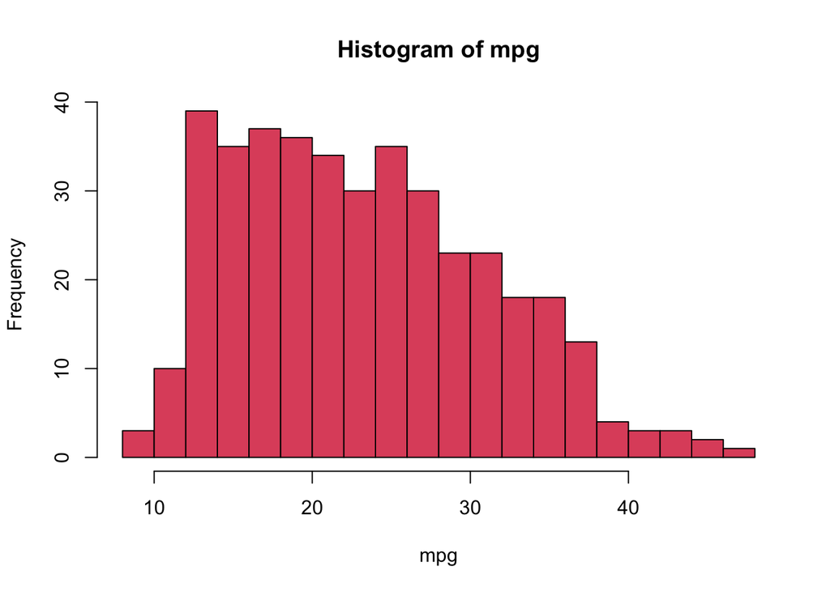

```r
hist(mpg, col=2, breaks = 17)
```

`pairs()` creates a pairplot of scatterplot.

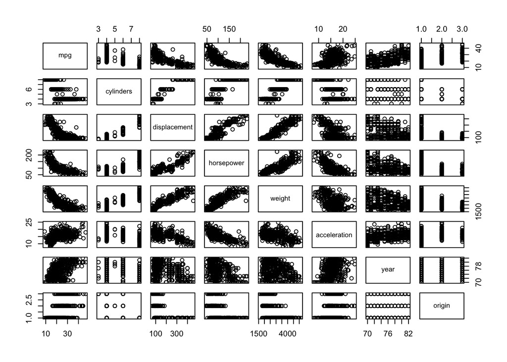

```r
pairs(auto[, -ncol(auto)]) # remove chr column
```

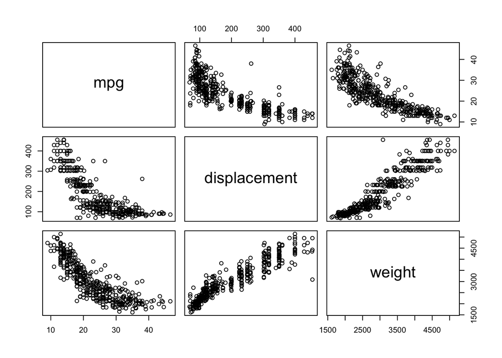

```r
pairs(~ mpg + displacement + weight, auto) # ~ denotes a formula specification in R.
```

```r
summary(auto)
```

```
##       mpg          cylinders      displacement     horsepower        weight
##  Min.   : 9.00   Min.   :3.000   Min.   : 68.0   Min.   : 46.0   Min.   :1613
##  1st Qu.:17.50   1st Qu.:4.000   1st Qu.:104.0   1st Qu.: 75.0   1st Qu.:2223
##  Median :23.00   Median :4.000   Median :146.0   Median : 93.5   Median :2800
##  Mean   :23.52   Mean   :5.458   Mean   :193.5   Mean   :104.5   Mean   :2970
##  3rd Qu.:29.00   3rd Qu.:8.000   3rd Qu.:262.0   3rd Qu.:126.0   3rd Qu.:3609
##  Max.   :46.60   Max.   :8.000   Max.   :455.0   Max.   :230.0   Max.   :5140
##                                                  NA's   :5
##   acceleration        year           origin          name
##  Min.   : 8.00   Min.   :70.00   Min.   :1.000   Length:397
##  1st Qu.:13.80   1st Qu.:73.00   1st Qu.:1.000   Class :character
##  Median :15.50   Median :76.00   Median :1.000   Mode  :character
##  Mean   :15.56   Mean   :75.99   Mean   :1.574
##  3rd Qu.:17.10   3rd Qu.:79.00   3rd Qu.:2.000
##  Max.   :24.80   Max.   :82.00   Max.   :3.000
##
```

```r
summary(mpg)
```

```
##    Min. 1st Qu.  Median    Mean 3rd Qu.    Max.
##    9.00   17.50   23.00   23.52   29.00   46.60
```

## Exercise 2.4 Q8

Here, we are using the `College` data set, found in `College.csv`. Before reading the data into R, it can be viewed in Excel or a text editor.

1. Use the `read.csv()` function to read the data into R. Call the loaded data `college`. Make sure that you have the directory set to the correct location for the data.

```r
college = read.csv('College.csv', stringsAsFactors = TRUE)
head(college, 3)
```

```
##                              X Private Apps Accept Enroll Top10perc Top25perc
## 1 Abilene Christian University     Yes 1660   1232    721        23        52
## 2           Adelphi University     Yes 2186   1924    512        16        29
## 3               Adrian College     Yes 1428   1097    336        22        50
##   F.Undergrad P.Undergrad Outstate Room.Board Books Personal PhD Terminal
## 1        2885         537     7440       3300   450     2200  70       78
## 2        2683        1227    12280       6450   750     1500  29       30
## 3        1036          99    11250       3750   400     1165  53       66
##   S.F.Ratio perc.alumni Expend Grad.Rate
## 1      18.1          12   7041        60
## 2      12.2          16  10527        56
## 3      12.9          30   8735        54
```

2. Look at the data using the `fix()` function. You should notice that the first column is just the name of each university. We don’t really want R to treat this as data. However, it may be handy to have these names for later. Try the following commands:

```r
rownames(college)=college[,1]
head(college, 3)
```

```
##                                                         X Private Apps Accept
## Abilene Christian University Abilene Christian University     Yes 1660   1232
## Adelphi University                     Adelphi University     Yes 2186   1924
## Adrian College                             Adrian College     Yes 1428   1097
##                              Enroll Top10perc Top25perc F.Undergrad P.Undergrad
## Abilene Christian University    721        23        52        2885         537
## Adelphi University              512        16        29        2683        1227
## Adrian College                  336        22        50        1036          99
##                              Outstate Room.Board Books Personal PhD Terminal
## Abilene Christian University     7440       3300   450     2200  70       78
## Adelphi University              12280       6450   750     1500  29       30
## Adrian College                  11250       3750   400     1165  53       66
##                              S.F.Ratio perc.alumni Expend Grad.Rate
## Abilene Christian University      18.1          12   7041        60
## Adelphi University                12.2          16  10527        56
## Adrian College                    12.9          30   8735        54
```

```r
#fix(college)
```

You should see that there is now a `row.names` column with the name of each university recorded. This means that R has given each row a name corresponding to the appropriate university. R will not try to perform calculations on the row names. However, we still need to eliminate the first column in the data where the names are stored. Try

```r
college=college[,-1]
head(college, 3)
```

```
##                              Private Apps Accept Enroll Top10perc Top25perc
## Abilene Christian University     Yes 1660   1232    721        23        52
## Adelphi University               Yes 2186   1924    512        16        29
## Adrian College                   Yes 1428   1097    336        22        50
##                              F.Undergrad P.Undergrad Outstate Room.Board Books
## Abilene Christian University        2885         537     7440       3300   450
## Adelphi University                  2683        1227    12280       6450   750
## Adrian College                      1036          99    11250       3750   400
##                              Personal PhD Terminal S.F.Ratio perc.alumni Expend
## Abilene Christian University     2200  70       78      18.1          12   7041
## Adelphi University               1500  29       30      12.2          16  10527
## Adrian College                   1165  53       66      12.9          30   8735
##                              Grad.Rate
## Abilene Christian University        60
## Adelphi University                  56
## Adrian College                      54
```

```r
# fix(college)
```

Now you should see that the first data column is `Private`. Note that another column labeled `row.names` now appears before the `Private` column. However, this is not a data column but rather the name that R is giving to each row.